# Data Brief #2

Abbie Raza

26/11/2021

# 1. Research Question and Importance

Is there a relationship between socioeconomic status and substance use during the COVID-19 global pandemic? This is the research question I plan on exploring. In particular, I hoped to see if there was a correlation between factors like employment status and education level, which are markers of socioeconomic status, and consumption of cannabis and alcohol. This question is important because current reports have shown that unemployment has skyrocketed due to the global pandemic (Hensher, 2020), and thus has an impact on the socioeconomic status of individuals within North America. According to the same report by Hensher (2020), the extended economic problems caused by COVID-19 could lead to negative health outcomes such as increased substance misuse as a result of growing living costs, unemployment, and a lack of access to healthcare resources, all of which contribute to socioeconomic status. SES is important because it is a significant indicator explaining trends between substance use and SES (Phelan et.al, 2010). FTC suggests that SES has an impact on access to a wide range of resources that protect health and avoid health inequities, both socially and economically. Higher socioeconomic status has the unique ability to increase access to resources required to engage in preventative strategies to avoid poor health and hazardous habits, as well as to address health issues once they arise (Phelan et. al, 2010). Several studies have found the link between the two variables to be significant indicators for the other (Singh et. al, 2018) (Patrick et. al, 2012). However, the direction of causality between the two variables is unclear as there is no way to probabilistically discern whether substance use is dependent on SES or vice versa (Glei and Weinstein (2019), (Nicholson Jr., 2020). Many studies have hypothesized that they both potentially contribute to the other.

In general, the specific trends for substance use have shown that higher alcohol use is correlated with a higher SES, whereas substances like cannabis and opioids are correlated with a lower SES. In both cases, the type of substance is correlated strongly with the level of SES. Based on this previous research, we should expect to see consistent results. For those of higher socioeconomic status (i.e. those who hold a bachelor’s degree or higher and are employed), we can expect to see higher rates of alcohol use. And for those with lower socioeconomic status (i.e. those who do not hold a bachelor’s degree and are unemployed), we can expect to see higher rates of cannabis use.

# 2.) Methods

- necessary libraries
- necessary functions and previous code

```r
Mode <- function(x) {
a = table(x)    # x is a vector   # function to return mode value
return(a[which.max(a)])
}


data <- read.csv("cpss-5311-E-2021-sus_F1.csv", header=TRUE) # original
d1 <- subset(subset(data,select = c(PEDUC_LC, PEMPSTC, ALC_05,ALC_20,ALC_35,CAN_05,CAN_15,CAN_30)))
d1 <- na.omit(d1)

d1$BAPLUS <- rep(0,length(d1$PEDUC_LC))
d1$BAPLUS <- ifelse(d1$PEDUC_LC >= 6, "Bachelor's", "No Bachelor's")
table(d1$BAPLUS)
```

```
##
##    Bachelor's No Bachelor's
##          1576          2365
```

```r
d1$EMPLOY <- rep(0,length(d1$PEMPSTC))
d1$EMPLOY[d1$PEMPSTC == 1] <- "Employed and at work"
d1$EMPLOY[d1$PEMPSTC == 2 | d1$PEMPSTC == 3] <- "Employed but absent from work"
d1$EMPLOY[d1$PEMPSTC == 4] <- "Not employed"

d1$EMPLOY <- factor(d1$EMPLOY,
                       levels = c("Employed and at work",
                                  "Employed but absent from work",

                                  "Not employed"))
table(d1$EMPLOY)
```

```
##
##          Employed and at work Employed but absent from work
##                          2148                           147
##                  Not employed
##                          1545
```

```r
d1$ALCFREQ <- rep(0,length(d1$ALC_05))
d1$ALCFREQ [d1$ALC_05 ==1] <- "Yes"
d1$ALCFREQ [d1$ALC_05 == 2] <- "No"
d1$ALCFREQ [d1$ALC_05 == 3] <- "Never Drank Alcohol"

d1$ALCFREQ <- factor(d1$ALCFREQ,
                       levels = c("Yes",
                                  "No",
                                  "Never Drank Alcohol"))
table(d1$ALCFREQ)
```

```
##
##                 Yes                  No Never Drank Alcohol
##                2703                 633                 603
```

```r
d1$ALCCON <- rep(0,length(d1$ALC_20))
d1$ALCCON [d1$ALC_20 == 1] <- "Increased"
d1$ALCCON [d1$ALC_20 == 2] <- "Decreased"
d1$ALCCON [d1$ALC_20 == 4] <- "Same"
d1$ALCCON [d1$ALC_20 == 3 | d1$ALC_20 == 6] <- "Not Applicable/ Valid Skip"

d1$ALCCON <- factor(d1$ALCCON,
                       levels = c("Increased",
                                  "Decreased",
                                  "Same", "Not Applicable/ Valid Skip"))
table(d1$ALCCON)
```

```
##
##                  Increased                  Decreased
##                        700                        608
##                       Same Not Applicable/ Valid Skip
##                       1780                        840
```

```r
d1$ALCPROB <- rep(0,length(d1$ALC_35))
d1$ALCPROB [d1$ALC_35 == 1] <- "Yes"
d1$ALCPROB [d1$ALC_35 == 2] <- "No"
d1$ALCPROB [d1$ALC_35 == 6] <- "Valid Skip"

d1$ALCPROB <- factor(d1$ALCPROB,
                       levels = c("Yes",
                                  "No",
                                  "Valid Skip"))
table(d1$ALCPROB)
```

```
##
##        Yes         No Valid Skip
##        221       2596       1121
```

```r
d1$CANFREQ <- rep(0,length(d1$CAN_05))
d1$CANFREQ [d1$CAN_05 == 1] <- "Never used cannabis"
d1$CANFREQ [d1$CAN_05 == 2] <- "Not in the past 30 days"
d1$CANFREQ [d1$CAN_05 == 3 | d1$CAN_05 == 4] <- "At least 1-3 times in the past 30 days"
d1$CANFREQ [d1$CAN_05 >= 5 & d1$CAN_05 < 8] <- "At least once a week"
d1$CANFREQ [d1$CAN_05 == 8] <- "daily"

d1$CANFREQ <- factor(d1$CANFREQ,
                       levels = c("Never used cannabis",
                                  "Not in the past 30 days",
                                  "At least 1-3 times in the past 30 days",
                                  "At least once a week",
                                  "daily"))
table(d1$CANFREQ)
```

```
##
##                    Never used cannabis                Not in the past 30 days
##                                   2811                                    508
## At least 1-3 times in the past 30 days                   At least once a week
##                                    233                                    211
##                                  daily
##                                    176
```

```r
# recode CAN_15 how has cannabis increased (CANCON)
d1$CANCON <- rep(0,length(d1$CAN_15))
d1$CANCON [d1$CAN_15 == 1] <- "Increased"
d1$CANCON [d1$CAN_15 == 2] <- "Decreased"
d1$CANCON [d1$CAN_15 == 4] <- "Same"
d1$CANCON [d1$CAN_15 == 3 | d1$CAN_15 == 6] <- "Not Applicable/ Valid Skip"

d1$CANCON <- factor(d1$CANCON,
                       levels = c("Increased",
                                  "Decreased",
                                  "Same",
                                  "Not Applicable/ Valid Skip"))
table(d1$CANCON)
```

```
##
##                  Increased                  Decreased
##                        251                         92
##                       Same Not Applicable/ Valid Skip
##                        451                       3145
```

```r
# recode CAN_30 to CANPROB

d1$CANPROB <- rep(0,length(d1$CAN_30))
d1$CANPROB [d1$CAN_30 == 1] <- "Yes"
d1$CANPROB [d1$CAN_30 == 2] <- "No"
d1$CANPROB [d1$CAN_30 == 6] <- "Valid Skip"

d1$CANPROB <- factor(d1$CANPROB,
                       levels = c("Yes",
                                  "No",
                                  "Valid Skip"))
table(d1$CANPROB)
```

```
##
##        Yes         No Valid Skip
##         65        598       3278
```

```r
d1 <- na.omit(d1)
```

- subsetting cannabis and alcohol into two separate data sets

```r
# cannabis
cann <- subset(subset(d1, select = c(CANCON, CANPROB, EMPLOY, BAPLUS)))
cann <- subset(subset(cann, d1$CANCON != "Not Applicable/ Valid Skip" & d1$CANPROB != "Valid Skip"), na.rm = TRUE)


# alcohol
alc <- subset(subset(d1, select = c(ALCCON, ALCPROB, EMPLOY, BAPLUS)))
alc <- subset(subset(alc, d1$ALCCON != "Not Applicable/ Valid Skip" & d1$ALCPROB != "Valid Skip"), na.rm = TRUE)
alc <- na.omit(alc)
```

Measures of Association- ALCFREQ and BAPLUS/EMPLOY - Does an association exist? - How strong is the association? - What is the pattern or direction of the association?

```r
round(prop.table(table(d1$ALCFREQ))*100,2)
```

```
##
##                 Yes                  No Never Drank Alcohol
##               68.78               16.03               15.19
```

```r
round(prop.table(table(d1$ALCFREQ, d1$BAPLUS))*100,2)
```

```
##
##                       Bachelor's No Bachelor's
##   Yes                      28.97         39.81
##   No                        5.92         10.11
##   Never Drank Alcohol       5.66          9.53
```

```r
round(prop.table(table(d1$ALCFREQ, d1$EMPLOY))*100,2)
```

```
##
##                       Employed and at work Employed but absent from work
##   Yes                                40.39                          2.41
##   No                                  8.22                          0.81
##   Never Drank Alcohol                 7.44                          0.60
##
##                       Not employed
##   Yes                        25.98
##   No                          6.99
##   Never Drank Alcohol         7.15
```

```r
# given that a person is employed, what is the probability that they also consumed alcohol?
round(prop.table(table(d1$ALCFREQ, d1$EMPLOY), margin = 1),2) # option 1
```

```
##
##                       Employed and at work Employed but absent from work
##   Yes                                 0.59                          0.04
##   No                                  0.51                          0.05
##   Never Drank Alcohol                 0.49                          0.04
##
##                       Not employed
##   Yes                         0.38
##   No                          0.44
##   Never Drank Alcohol         0.47
```

```r
CrossTable(d1$ALCFREQ, d1$EMPLOY,
            prop.c = FALSE, prop.t = TRUE,
            prop.r = TRUE, prop.chisq = FALSE, total.r = TRUE,
            total.c = TRUE) # option 2
```

```
##    Cell Contents
## |-------------------------|
## |                       N |
## |           N / Row Total |
## |         N / Table Total |
## |-------------------------|
##
## ==============================================================================
##                     d1$EMPLOY
## d1$ALCFREQ          Emplyd and at wr   Emplyd bt ab f w   Not employed   Total
## ------------------------------------------------------------------------------
## Yes                             1542                 92            992    2626
##                                0.587              0.035          0.378   0.688
##                                0.404              0.024          0.260
## ------------------------------------------------------------------------------
## No                               314                 31            267     612
##                                0.513              0.051          0.436   0.160
##                                0.082              0.008          0.070
## ------------------------------------------------------------------------------
## Never Drnk Alchl                 284                 23            273     580
##                                0.490              0.040          0.471   0.152
##                                0.074              0.006          0.072
## ------------------------------------------------------------------------------
## Total                           2140                146           1532    3818
## ==============================================================================
```

```r
# given that a person has at least a bachelor's, what is the probability that they also drank alcohol?
round(prop.table(table(d1$ALCFREQ, d1$BAPLUS), margin = 1),2)
```

```
##
##                       Bachelor's No Bachelor's
##   Yes                       0.42          0.58
##   No                        0.37          0.63
##   Never Drank Alcohol       0.37          0.63
```

```r
CrossTable(d1$ALCFREQ, d1$BAPLUS,
            prop.c = FALSE, prop.t = TRUE,
            prop.r = TRUE, prop.chisq = FALSE, total.r = TRUE,
            total.c = TRUE) # option 2
```

```
##    Cell Contents
## |-------------------------|
## |                       N |
## |           N / Row Total |
## |         N / Table Total |
## |-------------------------|
##
## =========================================================
##                        d1$BAPLUS
## d1$ALCFREQ             Bachelor's   No Bachelor's   Total
## ---------------------------------------------------------
## Yes                          1106            1520    2626
##                             0.421           0.579   0.688
##                             0.290           0.398
## ---------------------------------------------------------
## No                            226             386     612
##                             0.369           0.631   0.160
##                             0.059           0.101
## ---------------------------------------------------------
## Never Drank Alcohol           216             364     580
##                             0.372           0.628   0.152
##                             0.057           0.095
## ---------------------------------------------------------
## Total                        1548            2270    3818
## =========================================================
```

```r
# --------- CHI SQUARED TEST ---------
# Null Hypothesis: H0: there is no significant relationship between consuming alcohol in the past 30 days and employment status
chisq.test(d1$ALCFREQ, d1$EMPLOY)
```

```
##
##  Pearson's Chi-squared test
##
## data:  d1$ALCFREQ and d1$EMPLOY
## X-squared = 26.645, df = 4, p-value = 2.345e-05
```

```r
# Null Hypothesis: H0: there is no significant relationship between consuming alcohol in the past 30 days and whether or not respondents hold at least a bachelor's degree
chisq.test(d1$ALCFREQ, d1$BAPLUS)
```

```
##
##  Pearson's Chi-squared test
##
## data:  d1$ALCFREQ and d1$BAPLUS
## X-squared = 8.6401, df = 2, p-value = 0.0133
```

```r
# measure of associations- employment status and ALCFREQ
GoodmanKruskalGamma(d1$ALCFREQ, d1$EMPLOY)
```

```
## [1] 0.1475913
```

```r
# measure of association- education level and ALCFREQ
GoodmanKruskalGamma(d1$ALCFREQ, d1$BAPLUS)
```

```
## [1] 0.09391114
```

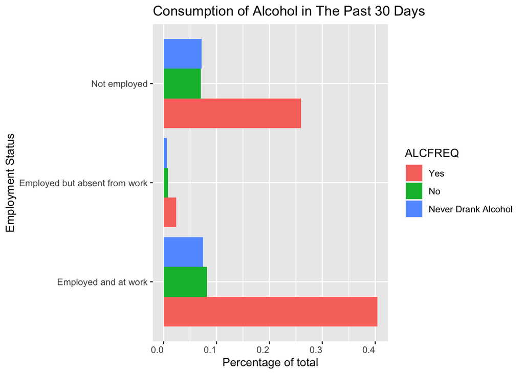

```r
# barplot- CANFREQ and EMPLOY
ggplot(data = subset(d1, !is.na(ALCFREQ)), aes(x = EMPLOY, y = (..count..)/sum(..count..), fill = ALCFREQ)) +
  geom_bar(position = "dodge") +
    labs(x = "Employment Status",
       y = "Percentage of total",
       title = "Consumption of Alcohol in The Past 30 Days") +
  theme(axis.text.x = element_text(angle = 0,
                                   hjust = 1)) + coord_flip()
```

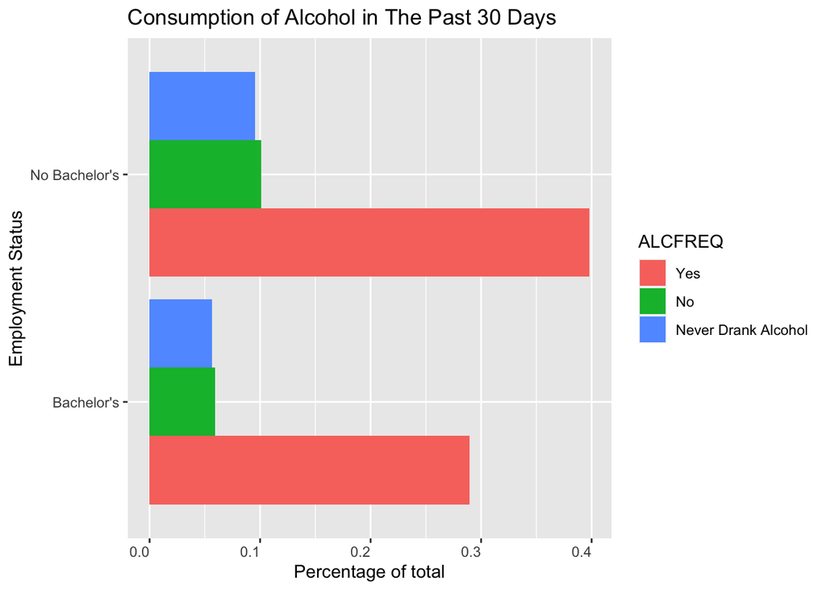

```r
# barplot- CANFREQ and BAPLUS
ggplot(data = subset(d1, !is.na(ALCFREQ)), aes(x = BAPLUS, y = (..count..)/sum(..count..), fill = ALCFREQ)) +
  geom_bar(position = "dodge") +
    labs(x = "Employment Status",
       y = "Percentage of total",
       title = "Consumption of Alcohol in The Past 30 Days") +
  theme(axis.text.x = element_text(angle = 0,
                                   hjust = 1)) + coord_flip()
```

- Measures of Association (CANFREQ and EMPLOY/BAPLUS)

```r
round(prop.table(table(d1$CANFREQ))*100,2)
```

```
##
##                    Never used cannabis                Not in the past 30 days
##                                  71.42                                  13.07
## At least 1-3 times in the past 30 days                   At least once a week
##                                   5.76                                   5.37
##                                  daily
##                                   4.37
```

```r
round(prop.table(table(d1$CANFREQ, d1$BAPLUS))*100,2)
```

```
##
##                                          Bachelor's No Bachelor's
##   Never used cannabis                         28.76         42.67
##   Not in the past 30 days                      6.18          6.89
##   At least 1-3 times in the past 30 days       2.25          3.51
##   At least once a week                         2.10          3.27
##   daily                                        1.26          3.12
```

```r
round(prop.table(table(d1$CANFREQ, d1$EMPLOY))*100,2)
```

```
##
##                                          Employed and at work
##   Never used cannabis                                   37.35
##   Not in the past 30 days                                8.59
##   At least 1-3 times in the past 30 days                 4.01
##   At least once a week                                   3.77
##   daily                                                  2.33
##
##                                          Employed but absent from work
##   Never used cannabis                                             2.33
##   Not in the past 30 days                                         0.58
##   At least 1-3 times in the past 30 days                          0.34
##   At least once a week                                            0.29
##   daily                                                           0.29
##
##                                          Not employed
##   Never used cannabis                           31.74
##   Not in the past 30 days                        3.90
##   At least 1-3 times in the past 30 days         1.41
##   At least once a week                           1.31
##   daily                                          1.75
```

```r
# given that a person is employed, what is the probability that they also consumed cannabis?
CrossTable(d1$CANFREQ, d1$EMPLOY,
            prop.c = FALSE, prop.t = TRUE,
            prop.r = TRUE, prop.chisq = FALSE, total.r = TRUE,
            total.c = TRUE)
```

```
##    Cell Contents
## |-------------------------|
## |                       N |
## |           N / Row Total |
## |         N / Table Total |
## |-------------------------|
##
## ==============================================================================
##                     d1$EMPLOY
## d1$CANFREQ          Emplyd and at wr   Emplyd bt ab f w   Not employed   Total
## ------------------------------------------------------------------------------
## Never used cnnbs                1426                 89           1212    2727
##                                0.523              0.033          0.444   0.714
##                                0.373              0.023          0.317
## ------------------------------------------------------------------------------
## Nt in th ps 30 d                 328                 22            149     499
##                                0.657              0.044          0.299   0.131
##                                0.086              0.006          0.039
## ------------------------------------------------------------------------------
## A l 1-3 t i t p                  153                 13             54     220
##                                0.695              0.059          0.245   0.058
##                                0.040              0.003          0.014
## ------------------------------------------------------------------------------
## At lest onc a wk                 144                 11             50     205
##                                0.702              0.054          0.244   0.054
##                                0.038              0.003          0.013
## ------------------------------------------------------------------------------
## daily                             89                 11             67     167
##                                0.533              0.066          0.401   0.044
##                                0.023              0.003          0.018
## ------------------------------------------------------------------------------
## Total                           2140                146           1532    3818
## ==============================================================================
```

```r
# given that a person has at least a bachelor's, what is the probability that they also consumed cannabis?
CrossTable(d1$CANFREQ, d1$BAPLUS,
            prop.c = FALSE, prop.t = TRUE,
            prop.r = TRUE, prop.chisq = FALSE, total.r = TRUE,
            total.c = TRUE)
```

```
##    Cell Contents
## |-------------------------|
## |                       N |
## |           N / Row Total |
## |         N / Table Total |
## |-------------------------|
##
## ============================================================================
##                                           d1$BAPLUS
## d1$CANFREQ                                Bachelor's   No Bachelor's   Total
## ----------------------------------------------------------------------------
## Never used cannabis                             1098            1629    2727
##                                                0.403           0.597   0.714
##                                                0.288           0.427
## ----------------------------------------------------------------------------
## Not in the past 30 days                          236             263     499
##                                                0.473           0.527   0.131
##                                                0.062           0.069
## ----------------------------------------------------------------------------
## At least 1-3 times in the past 30 days            86             134     220
##                                                0.391           0.609   0.058
##                                                0.023           0.035
## ----------------------------------------------------------------------------
## At least once a week                              80             125     205
##                                                0.390           0.610   0.054
##                                                0.021           0.033
## ----------------------------------------------------------------------------
## daily                                             48             119     167
##                                                0.287           0.713   0.044
##                                                0.013           0.031
## ----------------------------------------------------------------------------
## Total                                           1548            2270    3818
## ============================================================================
```

```r
# --------- CHI SQUARED TEST ---------
# Null Hypothesis: H0: there is no significant relationship between consuming cannabis in the past 30 days and employment status
chisq.test(d1$CANFREQ, d1$EMPLOY)
```

```
##
##  Pearson's Chi-squared test
##
## data:  d1$CANFREQ and d1$EMPLOY
## X-squared = 91.495, df = 8, p-value = 2.311e-16
```

```r
# Null Hypothesis: H0: there is no significant relationship between consuming cannabis in the past 30 days and whether or not respondents hold at least a bachelor's degree
chisq.test(d1$CANFREQ, d1$BAPLUS)
```

```
##
##  Pearson's Chi-squared test
##
## data:  d1$CANFREQ and d1$BAPLUS
## X-squared = 19.56, df = 4, p-value = 0.00061
```

```r
# measure of associations- employment status and CANFREQ
GoodmanKruskalGamma(d1$CANFREQ, d1$EMPLOY)
```

```
## [1] -0.2379753
```

```r
# measure of association- education level and CANFREQ
GoodmanKruskalGamma(d1$CANFREQ, d1$BAPLUS)
```

```
## [1] 0.006751776
```

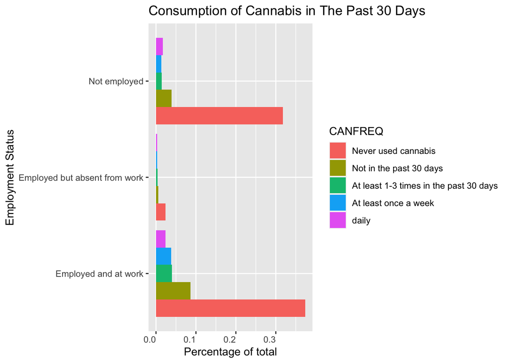

```r
# barplots
# barplot- CANFREQ and EMPLOY
ggplot(data = d1, aes(x = EMPLOY, y = (..count..)/sum(..count..), fill = CANFREQ)) +
  geom_bar(position = "dodge") +
    labs(x = "Employment Status",
       y = "Percentage of total",
       title = "Consumption of Cannabis in The Past 30 Days") +
  theme(axis.text.x = element_text(angle = 0,
                                   hjust = 1)) + coord_flip()
```

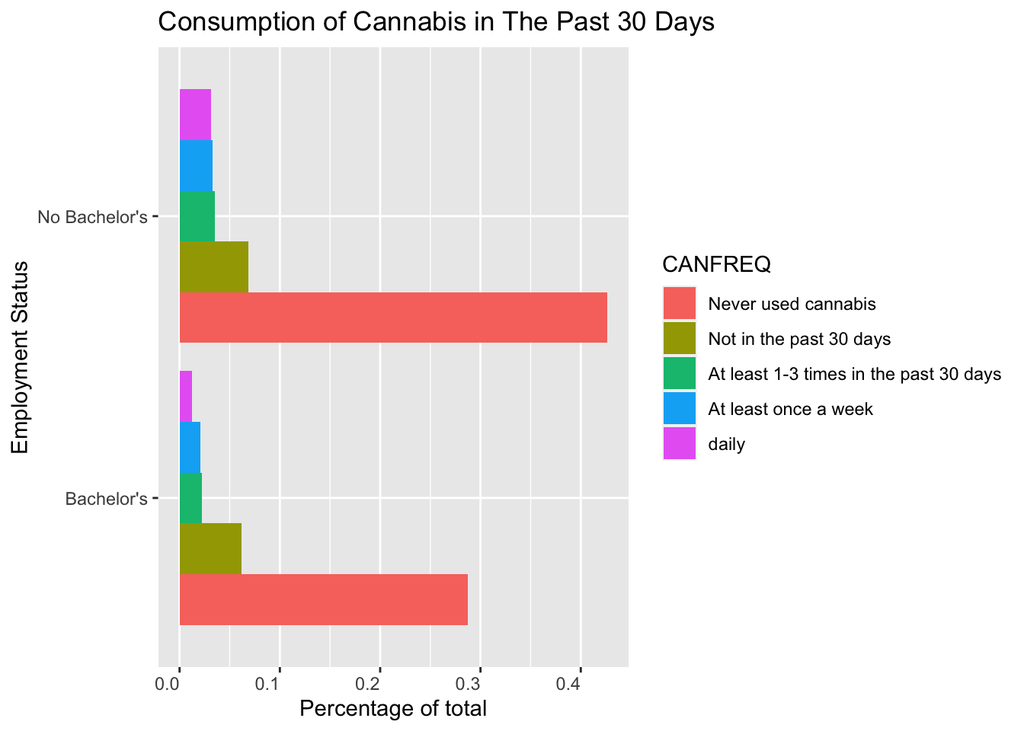

```r
# barplot- CANFREQ and BAPLUS
ggplot(data = d1, aes(x = BAPLUS, y = (..count..)/sum(..count..), fill = CANFREQ)) +
  geom_bar(position = "dodge") +
    labs(x = "Employment Status",
       y = "Percentage of total",
       title = "Consumption of Cannabis in The Past 30 Days") +
  theme(axis.text.x = element_text(angle = 0,
                                   hjust = 1)) + coord_flip()
```

- Measures of Association (Cannabis only)
- CANCON

```r
round(prop.table(table(cann$CANCON))*100,2)
```

```
##
##                  Increased                  Decreased
##                      37.74                      13.52
##                       Same Not Applicable/ Valid Skip
##                      48.74                       0.00
```

```r
round(prop.table(table(cann$CANCON, cann$EMPLOY))*100, 2)
```

```
##
##                              Employed and at work Employed but absent from work
##   Increased                                 25.47                          2.04
##   Decreased                                  9.43                          1.10
##   Same                                      30.35                          2.52
##   Not Applicable/ Valid Skip                 0.00                          0.00
##
##                              Not employed
##   Increased                         10.22
##   Decreased                          2.99
##   Same                              15.88
##   Not Applicable/ Valid Skip         0.00
```

```r
round(prop.table(table(cann$CANCON, cann$BAPLUS))*100, 2)
```

```
##
##                              Bachelor's No Bachelor's
##   Increased                       15.25         22.48
##   Decreased                        6.60          6.92
##   Same                            15.72         33.02
##   Not Applicable/ Valid Skip       0.00          0.00
```

```r
# --- CANCON
# given that a person is employed, how likely is it that they consume cannabis?
CrossTable(cann$CANCON, cann$EMPLOY,
           prop.c = FALSE, prop.t = TRUE,
           prop.r = TRUE, prop.chisq = FALSE, total.r = TRUE,
           total.c = TRUE)
```

```
##    Cell Contents
## |-------------------------|
## |                       N |
## |           N / Row Total |
## |         N / Table Total |
## |-------------------------|
##
## ===============================================================================
##                cann$EMPLOY
## cann$CANCON    Employed and at wrk   Emplyd bt absnt f w   Not employed   Total
## -------------------------------------------------------------------------------
## Increased                      162                    13             65     240
##                              0.675                 0.054          0.271   0.377
##                              0.255                 0.020          0.102
## -------------------------------------------------------------------------------
## Decreased                       60                     7             19      86
##                              0.698                 0.081          0.221   0.135
##                              0.094                 0.011          0.030
## -------------------------------------------------------------------------------
## Same                           193                    16            101     310
##                              0.623                 0.052          0.326   0.487
##                              0.303                 0.025          0.159
## -------------------------------------------------------------------------------
## Total                          415                    36            185     636
## ===============================================================================
```

```r
# given that a person holds at least a bachelor's degree, how likely is it that they consume cannabis?
CrossTable(cann$CANCON, cann$BAPLUS,
           prop.c = FALSE, prop.t = TRUE,
           prop.r = TRUE, prop.chisq = FALSE, total.r = TRUE,
           total.c = TRUE)
```

```
##    Cell Contents
## |-------------------------|
## |                       N |
## |           N / Row Total |
## |         N / Table Total |
## |-------------------------|
##
## =================================================
##                cann$BAPLUS
## cann$CANCON    Bachelor's   No Bachelor's   Total
## -------------------------------------------------
## Increased              97             143     240
##                     0.404           0.596   0.377
##                     0.153           0.225
## -------------------------------------------------
## Decreased              42              44      86
##                     0.488           0.512   0.135
##                     0.066           0.069
## -------------------------------------------------
## Same                  100             210     310
##                     0.323           0.677   0.487
##                     0.157           0.330
## -------------------------------------------------
## Total                 239             397     636
## =================================================
```

```r
# --------- CHI SQUARED TEST ---------
# Null Hypothesis: H0: there is no significant relationship frequency of cannabis consumption in the past 30 days and employment status
chisq.test(cann$CANCON, cann$EMPLOY)
```

```
##
##  Pearson's Chi-squared test
##
## data:  cann$CANCON and cann$EMPLOY
## X-squared = 5.0541, df = 4, p-value = 0.2818
```

```r
# Null Hypothesis: H0: there is no significant relationship between frequency of cannabis consumption in the past 30 days and whether or not respondents hold at least a bachelor's degree
chisq.test(cann$CANCON, cann$BAPLUS)
```

```
##
##  Pearson's Chi-squared test
##
## data:  cann$CANCON and cann$BAPLUS
## X-squared = 9.2124, df = 2, p-value = 0.00999
```

```r
# measure of associations- employment status and CANCON
GoodmanKruskalGamma(cann$CANCON, cann$EMPLOY)
```

```
## [1] 0.1000271
```

```r
# measure of association- education level and CANCON
GoodmanKruskalGamma(cann$CANCON, cann$BAPLUS)
```

```
## [1] 0.1504711
```

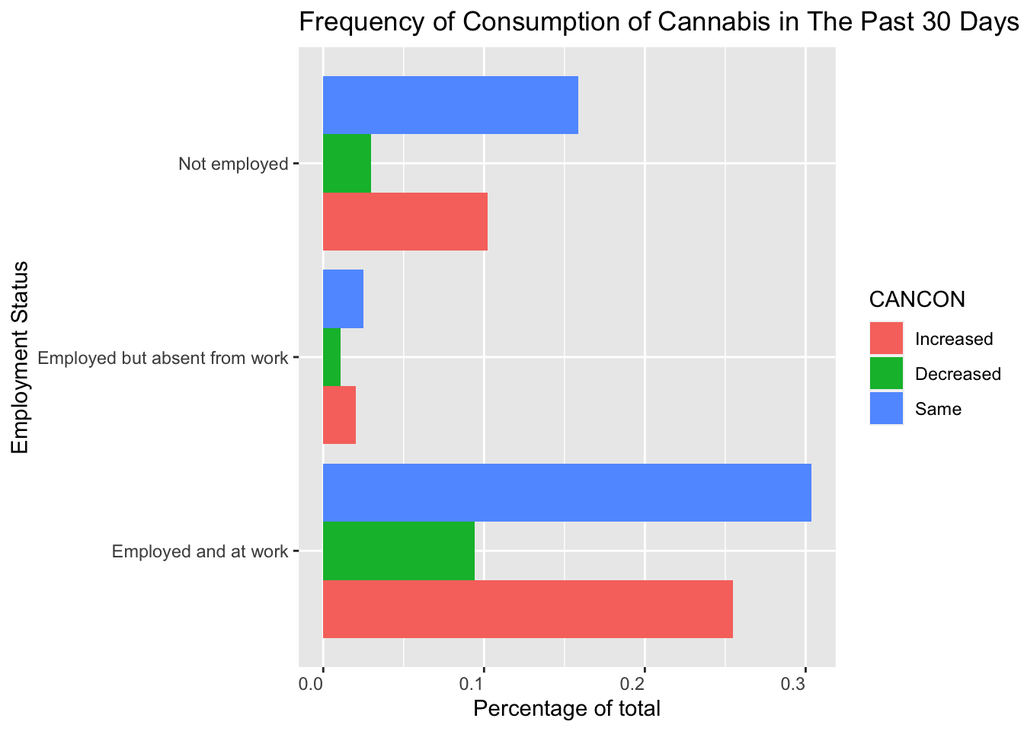

```r
# barplot- CANCON and EMPLOY
ggplot(data = subset(cann, !is.na(CANCON)), aes(x = EMPLOY, y = (..count..)/sum(..count..), fill = CANCON)) +
  geom_bar(position = "dodge") +
  labs(x = "Employment Status",
       y = "Percentage of total",
       title = "Frequency of Consumption of Cannabis in The Past 30 Days") +
  theme(axis.text.x = element_text(angle = 0,
                                   hjust = 1)) + coord_flip()
```

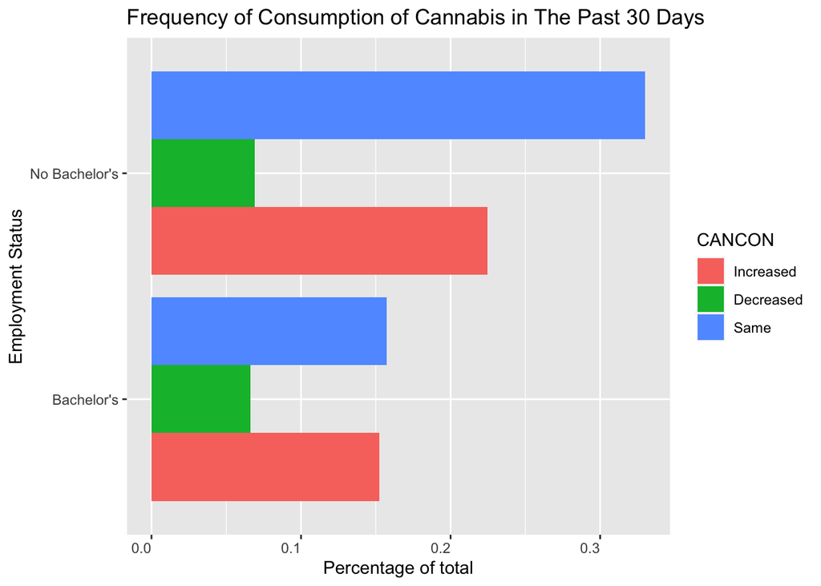

```r
# barplot- CANCON and BAPLUS
ggplot(data = subset(cann, !is.na(CANCON)), aes(x = BAPLUS, y = (..count..)/sum(..count..), fill = CANCON)) +
  geom_bar(position = "dodge") +
  labs(x = "Employment Status",
       y = "Percentage of total",
       title = "Frequency of Consumption of Cannabis in The Past 30 Days") +
  theme(axis.text.x = element_text(angle = 0,
                                   hjust = 1)) + coord_flip()
```

- CANPROB

```r
round(prop.table(table(cann$CANPROB))*100,2)
```

```
##
##        Yes         No Valid Skip
##       9.59      90.41       0.00
```

```r
round(prop.table(table(cann$CANPROB, cann$EMPLOY))*100, 2)
```

```
##
##              Employed and at work Employed but absent from work Not employed
##   Yes                        6.76                          0.79         2.04
##   No                        58.49                          4.87        27.04
##   Valid Skip                 0.00                          0.00         0.00
```

```r
round(prop.table(table(cann$CANPROB, cann$BAPLUS))*100, 2)
```

```
##
##              Bachelor's No Bachelor's
##   Yes              3.77          5.82
##   No              33.81         56.60
##   Valid Skip       0.00          0.00
```

```r
# --- CANPROB
# given that a person is employed, how likely is it that they consume cannabis knowing that they had a problem?
CrossTable(cann$CANPROB, cann$EMPLOY,
           prop.c = FALSE, prop.t = TRUE,
           prop.r = TRUE, prop.chisq = FALSE, total.r = TRUE,
           total.c = TRUE)
```

```
##    Cell Contents
## |-------------------------|
## |                       N |
## |           N / Row Total |
## |         N / Table Total |
## |-------------------------|
##
## ================================================================================
##                 cann$EMPLOY
## cann$CANPROB    Employed and at wrk   Emplyd bt absnt f w   Not employed   Total
## --------------------------------------------------------------------------------
## Yes                              43                     5             13      61
##                               0.705                 0.082          0.213   0.096
##                               0.068                 0.008          0.020
## --------------------------------------------------------------------------------
## No                              372                    31            172     575
##                               0.647                 0.054          0.299   0.904
##                               0.585                 0.049          0.270
## --------------------------------------------------------------------------------
## Total                           415                    36            185     636
## ================================================================================
```

```r
# given that a person holds at least a bachelor's degree, how likely is it that they consume cannabis knowing that they have a problem?
CrossTable(cann$CANPROB, cann$BAPLUS,
           prop.c = FALSE, prop.t = TRUE,
           prop.r = TRUE, prop.chisq = FALSE, total.r = TRUE,
           total.c = TRUE)
```

```
##    Cell Contents
## |-------------------------|
## |                       N |
## |           N / Row Total |
## |         N / Table Total |
## |-------------------------|
##
## ==================================================
##                 cann$BAPLUS
## cann$CANPROB    Bachelor's   No Bachelor's   Total
## --------------------------------------------------
## Yes                     24              37      61
##                      0.393           0.607   0.096
##                      0.038           0.058
## --------------------------------------------------
## No                     215             360     575
##                      0.374           0.626   0.904
##                      0.338           0.566
## --------------------------------------------------
## Total                  239             397     636
## ==================================================
```

```r
# --------- CHI SQUARED TEST ---------
# Null Hypothesis: H0: there is no significant relationship cannabis consumption problems in the past 30 days and employment status
chisq.test(cann$CANPROB, cann$EMPLOY)
```

```
##
##  Pearson's Chi-squared test
##
## data:  cann$CANPROB and cann$EMPLOY
## X-squared = 2.4535, df = 2, p-value = 0.2932
```

```r
fisher.test(cann$CANPROB, cann$EMPLOY)
```

```
##
##  Fisher's Exact Test for Count Data
##
## data:  cann$CANPROB and cann$EMPLOY
## p-value = 0.2531
## alternative hypothesis: two.sided
```

```r
# Null Hypothesis: H0: there is no significant relationship between cannabis consumption problems in the past 30 days and whether or not respondents hold at least a bachelor's degree
chisq.test(cann$CANPROB, cann$BAPLUS)
```

```
##
##  Pearson's Chi-squared test with Yates' continuity correction
##
## data:  cann$CANPROB and cann$BAPLUS
## X-squared = 0.02574, df = 1, p-value = 0.8725
```

```r
fisher.test(cann$CANPROB, cann$BAPLUS)
```

```
##
##  Fisher's Exact Test for Count Data
##
## data:  cann$CANPROB and cann$BAPLUS
## p-value = 0.782
## alternative hypothesis: two.sided
```

```r
# measure of associations- employment status and CANPROB
GoodmanKruskalGamma(cann$CANPROB, cann$EMPLOY)
```

```
## [1] 0.149209
```

```r
# measure of association- education level and CANPROB
GoodmanKruskalGamma(cann$CANPROB, cann$BAPLUS)
```

```
## [1] 0.04127749
```

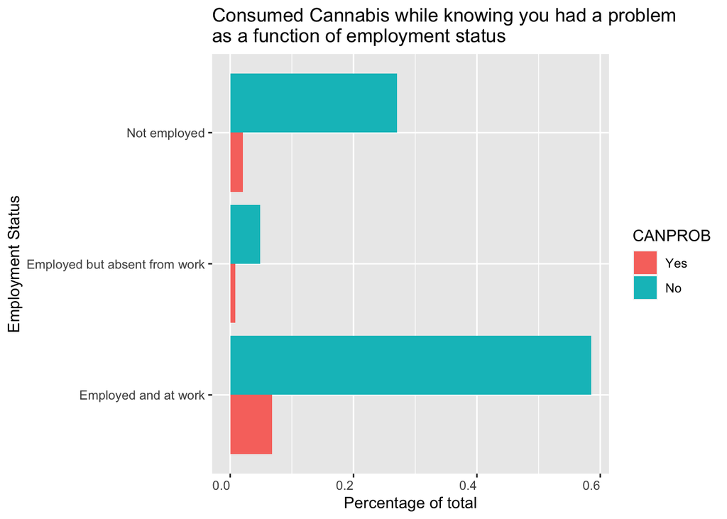

```r
# barplot- CANPROB and EMPLOY
ggplot(data = subset(cann, !is.na(CANPROB)), aes(x = EMPLOY, y = (..count..)/sum(..count..), fill = CANPROB)) +
  geom_bar(position = "dodge") +
  labs(x = "Employment Status",
       y = "Percentage of total",
       title = "Consumed Cannabis while knowing you had a problem\nas a function of employment status") +
  theme(axis.text.x = element_text(angle = 0,
                                   hjust = 1)) + coord_flip()
```

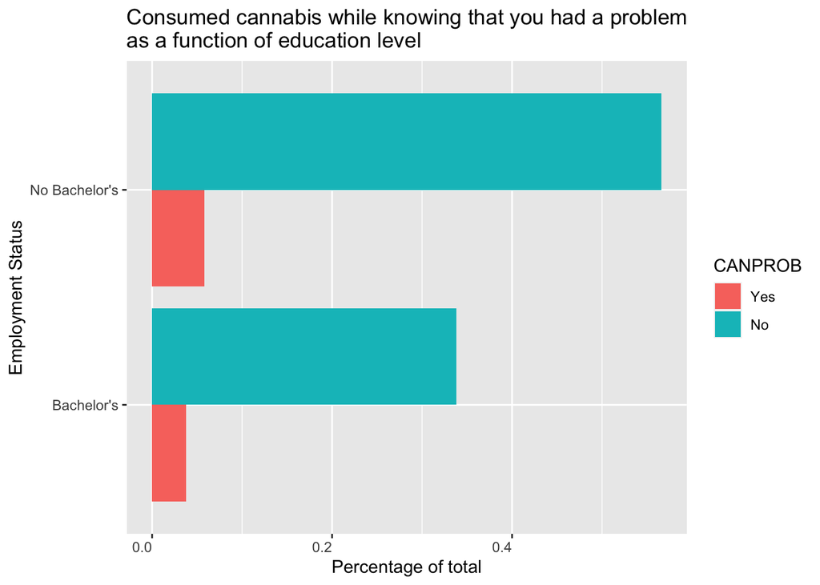

```r
# barplot- CANPROB and BAPLUS
ggplot(data = subset(cann, !is.na(CANPROB)), aes(x = BAPLUS, y = (..count..)/sum(..count..), fill = CANPROB)) +
  geom_bar(position = "dodge") +
  labs(x = "Employment Status",
       y = "Percentage of total",
       title = "Consumed cannabis while knowing that you had a problem\nas a function of education level") +
  theme(axis.text.x = element_text(angle = 0,
                                   hjust = 1)) + coord_flip()
```

- Measures of Association (Alcohol only)
- ALCPROB

```r
round(prop.table(table(alc$ALCPROB))*100,2)
```

```
##
##        Yes         No Valid Skip
##        7.8       92.2        0.0
```

```r
round(prop.table(table(alc$ALCPROB, alc$EMPLOY))*100, 2)
```

```
##
##              Employed and at work Employed but absent from work Not employed
##   Yes                        5.16                          0.51         2.12
##   No                        53.77                          3.11        35.31
##   Valid Skip                 0.00                          0.00         0.00
```

```r
round(prop.table(table(alc$ALCPROB, alc$BAPLUS))*100, 2)
```

```
##
##              Bachelor's No Bachelor's
##   Yes              2.93          4.87
##   No              39.27         52.93
##   Valid Skip       0.00          0.00
```

```r
# --- ALCPROB
# given that a person is employed, how likely is it that they consume alcohol knowing that they had a problem?
CrossTable(alc$ALCPROB, alc$EMPLOY,
           prop.c = FALSE, prop.t = TRUE,
           prop.r = TRUE, prop.chisq = FALSE, total.r = TRUE,
           total.c = TRUE)
```

```
##    Cell Contents
## |-------------------------|
## |                       N |
## |           N / Row Total |
## |         N / Table Total |
## |-------------------------|
##
## ===============================================================================
##                alc$EMPLOY
## alc$ALCPROB    Employed and at wrk   Emplyd bt absnt f w   Not employed   Total
## -------------------------------------------------------------------------------
## Yes                            141                    14             58     213
##                              0.662                 0.066          0.272   0.078
##                              0.052                 0.005          0.021
## -------------------------------------------------------------------------------
## No                            1468                    85            964    2517
##                              0.583                 0.034          0.383   0.922
##                              0.538                 0.031          0.353
## -------------------------------------------------------------------------------
## Total                         1609                    99           1022    2730
## ===============================================================================
```

```r
# given that a person holds at least a bachelor's degree, how likely is it that they consume alcohol knowing that they have a problem?
CrossTable(alc$ALCPROB, alc$BAPLUS,
           prop.c = FALSE, prop.t = TRUE,
           prop.r = TRUE, prop.chisq = FALSE, total.r = TRUE,
           total.c = TRUE)
```

```
##    Cell Contents
## |-------------------------|
## |                       N |
## |           N / Row Total |
## |         N / Table Total |
## |-------------------------|
##
## =================================================
##                alc$BAPLUS
## alc$ALCPROB    Bachelor's   No Bachelor's   Total
## -------------------------------------------------
## Yes                    80             133     213
##                     0.376           0.624   0.078
##                     0.029           0.049
## -------------------------------------------------
## No                   1072            1445    2517
##                     0.426           0.574   0.922
##                     0.393           0.529
## -------------------------------------------------
## Total                1152            1578    2730
## =================================================
```

```r
# --------- CHI SQUARED TEST ---------
# Null Hypothesis: H0: there is no significant relationship alcohol consumption problems in the past 30 days and employment status
chisq.test(alc$ALCPROB, alc$EMPLOY)
```

```
##
##  Pearson's Chi-squared test
##
## data:  alc$ALCPROB and alc$EMPLOY
## X-squared = 14.024, df = 2, p-value = 0.0009009
```

```r
# Null Hypothesis: H0: there is no significant relationship between alcohol consumption problems in the past 30 days and whether or not respondents hold at least a bachelor's degree
chisq.test(alc$ALCPROB, alc$BAPLUS)
```

```
##
##  Pearson's Chi-squared test with Yates' continuity correction
##
## data:  alc$ALCPROB and alc$BAPLUS
## X-squared = 1.8374, df = 1, p-value = 0.1753
```

```r
# measure of associations- employment status and ALCPROB
GoodmanKruskalGamma(alc$ALCPROB, alc$EMPLOY)
```

```
## [1] 0.1866662
```

```r
# measure of association- education level and ALCPROB
GoodmanKruskalGamma(alc$ALCPROB, alc$BAPLUS)
```

```
## [1] -0.1044869
```

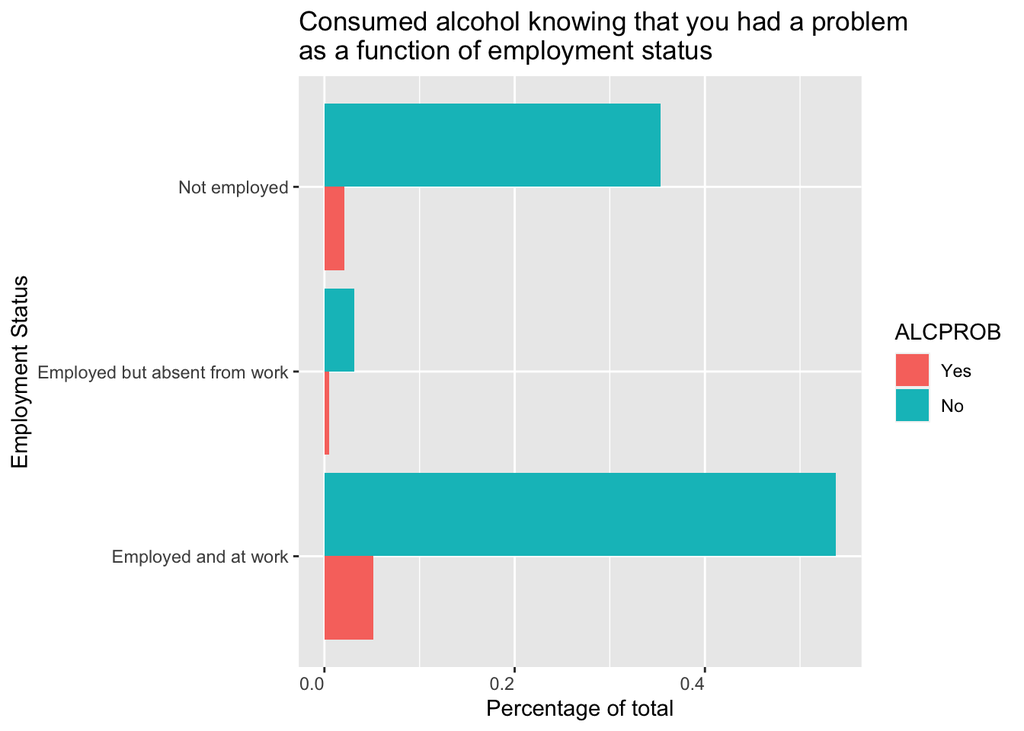

```r
# barplot- ALCPROB and EMPLOY
ggplot(data = subset(alc, !is.na(ALCPROB)), aes(x = EMPLOY, y = (..count..)/sum(..count..), fill = ALCPROB)) +
  geom_bar(position = "dodge") +
  labs(x = "Employment Status",
       y = "Percentage of total",
       title = "Consumed alcohol knowing that you had a problem\nas a function of employment status") +
  theme(axis.text.x = element_text(angle = 0,
                                   hjust = 1)) + coord_flip()
```

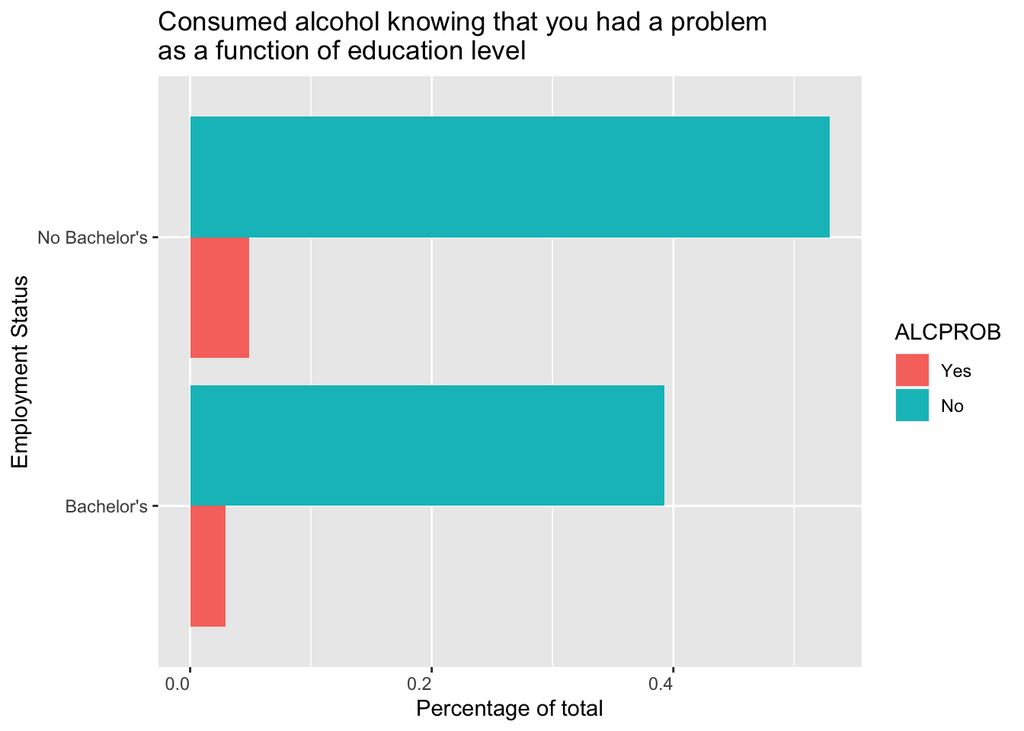

```r
# barplot- ALCPROB and BAPLUS
ggplot(data = subset(alc, !is.na(ALCPROB)), aes(x = BAPLUS, y = (..count..)/sum(..count..), fill = ALCPROB)) +
  geom_bar(position = "dodge") +
  labs(x = "Employment Status",
       y = "Percentage of total",
       title = "Consumed alcohol knowing that you had a problem\nas a function of education level") +
  theme(axis.text.x = element_text(angle = 0,
                                   hjust = 1)) + coord_flip()
```

- ALCCON

```r
round(prop.table(table(alc$ALCCON))*100,2)
```

```
##
##                  Increased                  Decreased
##                      25.09                      21.43
##                       Same Not Applicable/ Valid Skip
##                      53.48                       0.00
```

```r
round(prop.table(table(alc$ALCCON, alc$EMPLOY))*100, 2)
```

```
##
##                              Employed and at work Employed but absent from work
##   Increased                                 16.70                          1.17
##   Decreased                                 12.01                          0.84
##   Same                                      30.22                          1.61
##   Not Applicable/ Valid Skip                 0.00                          0.00
##
##                              Not employed
##   Increased                          7.22
##   Decreased                          8.57
##   Same                              21.65
##   Not Applicable/ Valid Skip         0.00
```

```r
round(prop.table(table(alc$ALCCON, alc$BAPLUS))*100, 2)
```

```
##
##                              Bachelor's No Bachelor's
##   Increased                       11.58         13.52
##   Decreased                        9.01         12.42
##   Same                            21.61         31.87
##   Not Applicable/ Valid Skip       0.00          0.00
```

```r
# --- ALCCON
# given that a person is employed, how likely is it that they consumed alcohol in the past 30 days?
CrossTable(alc$ALCCON, alc$EMPLOY,
           prop.c = FALSE, prop.t = TRUE,
           prop.r = TRUE, prop.chisq = FALSE, total.r = TRUE,
           total.c = TRUE)
```

```
##    Cell Contents
## |-------------------------|
## |                       N |
## |           N / Row Total |
## |         N / Table Total |
## |-------------------------|
##
## ================================================================================
##               alc$EMPLOY
## alc$ALCCON    Employed and at work   Emplyd bt absnt fr w   Not employed   Total
## --------------------------------------------------------------------------------
## Increased                      456                     32            197     685
##                              0.666                  0.047          0.288   0.251
##                              0.167                  0.012          0.072
## --------------------------------------------------------------------------------
## Decreased                      328                     23            234     585
##                              0.561                  0.039          0.400   0.214
##                              0.120                  0.008          0.086
## --------------------------------------------------------------------------------
## Same                           825                     44            591    1460
##                              0.565                  0.030          0.405   0.535
##                              0.302                  0.016          0.216
## --------------------------------------------------------------------------------
## Total                         1609                     99           1022    2730
## ================================================================================
```

```r
# given that a person consumed alcohol in the past 30 days, how likely is that they are employed?
CrossTable(alc$ALCCON, alc$EMPLOY,
           prop.c = TRUE, prop.t = TRUE,
           prop.r = FALSE, prop.chisq = FALSE, total.r = TRUE,
           total.c = TRUE)
```

```
##    Cell Contents
## |-------------------------|
## |                       N |
## |           N / Col Total |
## |         N / Table Total |
## |-------------------------|
##
## ================================================================================
##               alc$EMPLOY
## alc$ALCCON    Employed and at work   Emplyd bt absnt fr w   Not employed   Total
## --------------------------------------------------------------------------------
## Increased                      456                     32            197     685
##                              0.283                  0.323          0.193
##                              0.167                  0.012          0.072
## --------------------------------------------------------------------------------
## Decreased                      328                     23            234     585
##                              0.204                  0.232          0.229
##                              0.120                  0.008          0.086
## --------------------------------------------------------------------------------
## Same                           825                     44            591    1460
##                              0.513                  0.444          0.578
##                              0.302                  0.016          0.216
## --------------------------------------------------------------------------------
## Total                         1609                     99           1022    2730
##                              0.589                  0.036          0.374
## ================================================================================
```

```r
# given that a person holds at least a bachelor's degree, how likely is it that they consume alcohol in the past 30 days?
CrossTable(alc$ALCCON, alc$BAPLUS,
           prop.c = FALSE, prop.t = TRUE,
           prop.r = TRUE, prop.chisq = FALSE, total.r = TRUE,
           total.c = TRUE)
```

```
##    Cell Contents
## |-------------------------|
## |                       N |
## |           N / Row Total |
## |         N / Table Total |
## |-------------------------|
##
## ================================================
##               alc$BAPLUS
## alc$ALCCON    Bachelor's   No Bachelor's   Total
## ------------------------------------------------
## Increased            316             369     685
##                    0.461           0.539   0.251
##                    0.116           0.135
## ------------------------------------------------
## Decreased            246             339     585
##                    0.421           0.579   0.214
##                    0.090           0.124
## ------------------------------------------------
## Same                 590             870    1460
##                    0.404           0.596   0.535
##                    0.216           0.319
## ------------------------------------------------
## Total               1152            1578    2730
## ================================================
```

```r
# given that a person consumed alcohol in the past 30 days, how likely is it that they hold a bachelor's degree?
CrossTable(alc$ALCCON, alc$BAPLUS,
           prop.c = TRUE, prop.t = TRUE,
           prop.r = FALSE, prop.chisq = FALSE, total.r = TRUE,
           total.c = TRUE)
```

```
##    Cell Contents
## |-------------------------|
## |                       N |
## |           N / Col Total |
## |         N / Table Total |
## |-------------------------|
##
## ================================================
##               alc$BAPLUS
## alc$ALCCON    Bachelor's   No Bachelor's   Total
## ------------------------------------------------
## Increased            316             369     685
##                    0.274           0.234
##                    0.116           0.135
## ------------------------------------------------
## Decreased            246             339     585
##                    0.214           0.215
##                    0.090           0.124
## ------------------------------------------------
## Same                 590             870    1460
##                    0.512           0.551
##                    0.216           0.319
## ------------------------------------------------
## Total               1152            1578    2730
##                    0.422           0.578
## ================================================
```

```r
# --------- CHI SQUARED TEST ---------
# Null Hypothesis: H0: there is no significant relationship alcohol consumption in the past 30 days and employment status
chisq.test(alc$ALCCON, alc$EMPLOY)
```

```
##
##  Pearson's Chi-squared test
##
## data:  alc$ALCCON and alc$EMPLOY
## X-squared = 31.191, df = 4, p-value = 2.799e-06
```

```r
# Null Hypothesis: H0: there is no significant relationship between alcohol consumption in the past 30 days and whether or not respondents hold at least a bachelor's degree
chisq.test(alc$ALCCON, alc$BAPLUS)
```

```
##
##  Pearson's Chi-squared test
##
## data:  alc$ALCCON and alc$BAPLUS
## X-squared = 6.2617, df = 2, p-value = 0.04368
```

```r
# measure of associations- employment status and ALCCON
GoodmanKruskalGamma(alc$ALCCON, alc$EMPLOY)
```

```
## [1] 0.1346531
```

```r
# measure of association- education level and ALCCON
GoodmanKruskalGamma(alc$ALCCON, alc$BAPLUS)
```

```
## [1] 0.07928058
```

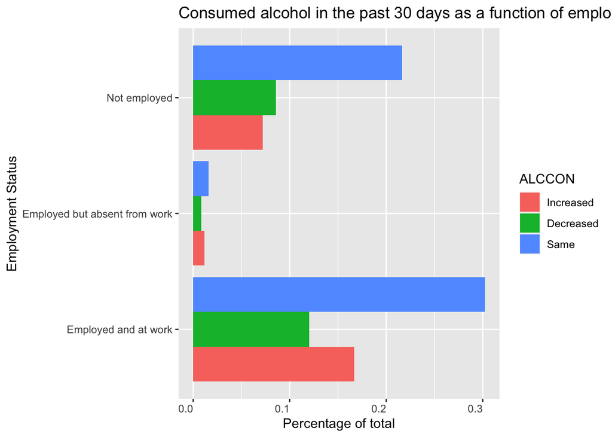

```r
# barplot- ALCCON and EMPLOY
ggplot(data = subset(alc, !is.na(ALCCON)), aes(x = EMPLOY, y = (..count..)/sum(..count..), fill = ALCCON)) +
  geom_bar(position = "dodge") +
  labs(x = "Employment Status",
       y = "Percentage of total",
       title = "Consumed alcohol in the past 30 days as a function of employment status") +
  theme(axis.text.x = element_text(angle = 0,
                                   hjust = 1)) + coord_flip()
```

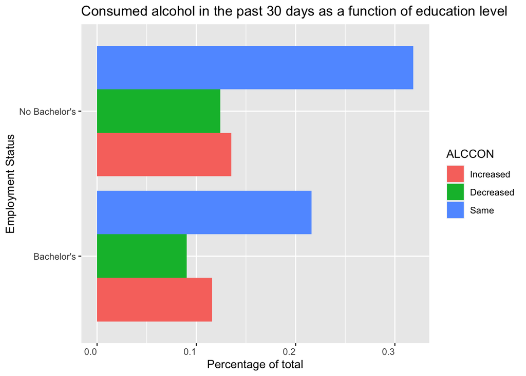

```r
# barplot- ALCCON and BAPLUS
ggplot(data = subset(alc, !is.na(ALCCON)), aes(x = BAPLUS, y = (..count..)/sum(..count..), fill = ALCCON)) +
  geom_bar(position = "dodge") +
  labs(x = "Employment Status",
       y = "Percentage of total",
       title = "Consumed alcohol in the past 30 days as a function of education level") +
  theme(axis.text.x = element_text(angle = 0,
                                   hjust = 1)) + coord_flip()
```

To test for significance, I used a chi-squared test of significance. Finally, to measure the strength of the association between the dependent and independent variables, I used Goodman-Kruskal Gamma.

ALCFREQ and EMPLOY/BAPLUS

Starting with ALCFREQ, which is the frequency of alcohol consumption in the past 30 days, roughly 68.8% of the respondents answered yes. 39.81% did not hold a bachelor’s degree, compared to those who did hold a bachelor’s degree at 28.97%. When it came to employment status, 42.8% of those who were currently employed reported consuming alcohol. These results are consistent with the conditional bar plots. When comparing cross-tabulated data, given that a person is employed, they were more likely to consume alcohol at least once in the past 30 days compared to those who were absent from work and those who were currently unemployed. Of those who were employed (both at work or absent from work), employed respondents were more likely to consume alcohol compared to unemployed respondents. Following this, those who held (at least) a bachelor’s degree were less likely to consume alcohol than those without a bachelor’s degree in the past 30 days. For the Chi-squared test between ALCFREQ and EMPLOY, the p-value is significant at a p <0.05 confidence interval. In other words, the association between the frequency of alcohol consumption and their employment status is significant 95% of the time. When it came to ALCFREQ and BAPLUS, the p-value is significant at p < 0.05. So the association between frequency of alcohol consumption and education level is significant, a result we can be sure of 95% of the time. Finally, when looking at the Goodman-Kruskal Gamma, the strength of association between ALCFREQ and EMPLOY was weak at roughly 0.15. The association between ALCFREQ and BAPLUS was negligible at roughly 0.094.

CANFREQ and EMPLOY/BAPLUS

CANCON and EMPLOY/BAPLUS

Of the respondents who claimed to have used cannabis in the past 30 days, those who were employed claimed that their cannabis consumption had remained relatively the same for the most part. The same can be said for those who are unemployed as well. When it came to education level, those who held at least a bachelor’s degree reported that their cannabis consumption remained the same for the most part, however, the increase in cannabis use was nearly the same proportion to those who claim that their cannabis consumption had remained the same. There was a much larger gap between unemployed respondents, where a larger majority claimed that their cannabis consumption remained the same. The chi-squared test between CANCON and EMPLOY yielded an insignificant p-value at p < 0.05. Therefore, we fail to reject the null hypothesis that there is no significant relationship between cannabis use and employment status. In other words, the association between the consumption of cannabis use trends and employment status is insignificant 95% of the time. For the same confidence interval, the relationship between BAPLUS and CANCON is significant at p < 0.05. The Goodman-Kruskal Gamma between employment status and CANCON was 0.10, indicating a weak relationship between the two variables. The same can be said between education level and CANCON at 0.15, which is slightly higher than the relationship between CANCON and employment status, but still weak.

CANPROB and EMPLOY/BAPLUS

Of The respondents who claimed to have used cannabis in the past 30 days, The majority of respondents claimed that they had not consumed cannabis knowing that they had a problem. Of the 61 people who reported that they consume cannabis while knowing that they had a problem, 43 of them were employed and at work and 5 of them were employed but absent from work, comprising 78.7% of those consuming cannabis while knowing that they had a problem- however, this proportion can also be explained by the number of people who were employed at work being a lot larger than those who were unemployed. The chi-squared test between CANPROB and EMPLOY yielded an insignificant p-value at p < 0.05. Therefore, we fail to reject the null hypothesis that there is no significant relationship between cannabis use problems and employment status. In other words, the association between the consumption of cannabis problem trends and employment status is insignificant 95% of the time. This was further confirmed by Fisher’s exact test. For BAPLUS and CANPROB, the chi-squared test also yielded an insignificant result at p < 0.05. Thus, the relationship between BAPLUS and CANCON is more likely due to random chance; we can be sure of this 95% of the time. The Goodman Kruskal Gamma for CANPROB and EMPLOY is weak at 1.5 and even weaker for education level at 0.04.

ALCCON and EMPLOY/BAPLUS

Of the respondents who responded yes to alcohol consumption (ALCFREQ) in the past 30 days, the majority of them responded to having the same level of consumption. However, when looking at the bar plot, the difference between the consumption of alcohol during the pandemic between those who were employed versus those who were unemployed, there were a couple differences. One, the proportion of employed people at work whose alcohol consumption increased was larger compared to the proportion of employed individuals at work whose alcohol consumption decreased. The opposite is true for unemployed respondents. Unemployed respondents saw a larger proportional decrease in alcohol consumption compared to an increase. Two, those who were employed but absent from work shared consistent trends with those who were employed, in that even individuals who were absent from work but still employed reported a noticed increase in alcohol use compared to a decrease. As for the level of education, there was a noticeable increase in both groups for alcohol consumption compared to a decrease. However, for the majority of individuals, alcohol consumption remained the same regardless of education level. The Chi-squared test for ALCCON and EMPLOY showed a significant p-value at p < 0.05. Therefore, we can reject the null hypothesis and conclude that there is a significant relationship between alcohol consumption and employment status, and we can be sure of this at the 95% confidence interval. The same is true for the relationship between ALCCON and BAPLUS. Therefore, we can conclude that there is a significant relationship between employment status and ALCCON and between education level and ALCCON. Goodman-Kruskal Gamma for ALCCON and EMPLOY was 0.13, showing a weak relationship between the two variables. For ALCCON and BAPLUS, this relationship was even weaker at 0.079.

ALCPROB and EMPLOY/BAPLUS

For both employment status and education level, the vast majority of respondents answered no, meaning that they had not consumed alcohol knowing that they had a problem. The Chi-squared test for ALCPROB and EMPLOY yielded a significant p-value at p <0.05. Therefore, we can reject the null hypothesis and conclude that there is a significant relationship between ALCPROB and EMPLOY, and we can be sure of this at the 95% confidence interval. However, the Chi-squared test for ALCPROB and BAPLUS was insignificant at p < 0.05. Therefore, we fail to reject the null hypothesis and conclude that there is no significant relationship between ALCPROB and BAPLUS. The Goodman-Kruskal Gamma measure of association for ALCPROB and EMPLOY was 0.19, indicating a weak to a moderate relationship. For ALCPROB and BAPLUS, the relationship was an inverse weak relationship. Those who had a higher level of education were less likely to consume alcohol knowing that they had a problem. However, this relationship is relatively weak.

# 3.) Analysis and Results

multivariate/ logistic regression between cannabis, employment, and education

- CANFREQ, ALCFREQ and EMPLOY/BAPLUS

```r
# recoded into logic variables
d1$CANFREQ2 <- rep(0,length(d1$CANFREQ))
d1$CANFREQ2 [d1$CANFREQ == "Never used cannabis" |
               d1$CANFREQ == "Not in the past 30 days" ] <- 1
# d1$CANFREQ2[d1$CANFREQ == "At least 1-3 times in the past 30 days"] <- 0
# d1$CANFREQ2[d1$CANFREQ == "At least once a week" | d1$CANFREQ == "daily"] <- 0
table(d1$CANFREQ2)
```

```
##
##    0    1
##  592 3226
```

```r
d1$ALCFREQ2 <- rep(0,length(d1$ALCFREQ))
d1$ALCFREQ2 [d1$ALCFREQ == "No" | d1$ALCFREQ == "Never Drank Alcohol"] <- 1
table(d1$ALCFREQ2)
```

```
##
##    0    1
## 2626 1192
```

```r
# logistic regression for CANFREQ
regCANFREQ2 <- glm(CANFREQ2 ~ EMPLOY + BAPLUS, family = binomial(link = logit), data = d1)
summary(regCANFREQ2)
```

```
##
## Call:
## glm(formula = CANFREQ2 ~ EMPLOY + BAPLUS, family = binomial(link = logit),
##     data = d1)
##
## Deviance Residuals:
##     Min       1Q   Median       3Q      Max
## -2.1792   0.4420   0.5072   0.6683   0.7728
##
## Coefficients:
##                                     Estimate Std. Error z value Pr(>|z|)
## (Intercept)                          1.67649    0.07853  21.348  < 2e-16 ***
## EMPLOYEmployed but absent from work -0.32990    0.20239  -1.630  0.10310
## EMPLOYNot employed                   0.60037    0.09966   6.024  1.7e-09 ***
## BAPLUSNo Bachelor's                 -0.29097    0.09404  -3.094  0.00197 **
## ---
## Signif. codes:  0 '***' 0.001 '**' 0.01 '*' 0.05 '.' 0.1 ' ' 1
##
## (Dispersion parameter for binomial family taken to be 1)
##
##     Null deviance: 3294.0  on 3817  degrees of freedom
## Residual deviance: 3243.1  on 3814  degrees of freedom
## AIC: 3251.1
##
## Number of Fisher Scoring iterations: 4
```

```r
PseudoR2(regCANFREQ2)
```

```
##   McFadden
## 0.01544584
```

```r
# logistic regression for ALCFREQ
regALCFREQ <- glm(ALCFREQ2 ~ EMPLOY + BAPLUS, family = binomial(link = logit), data = d1)
summary(regALCFREQ)
```

```
##
## Call:
## glm(formula = ALCFREQ2 ~ EMPLOY + BAPLUS, family = binomial(link = logit),
##     data = d1)
##
## Deviance Residuals:
##     Min       1Q   Median       3Q      Max
## -0.9839  -0.8900  -0.7785   1.4199   1.6381
##
## Coefficients:
##                                     Estimate Std. Error z value Pr(>|z|)
## (Intercept)                         -1.03866    0.06281 -16.536  < 2e-16 ***
## EMPLOYEmployed but absent from work  0.39704    0.17835   2.226    0.026 *
## EMPLOYNot employed                   0.31695    0.07263   4.364 1.28e-05 ***
## BAPLUSNo Bachelor's                  0.16768    0.07263   2.309    0.021 *
## ---
## Signif. codes:  0 '***' 0.001 '**' 0.01 '*' 0.05 '.' 0.1 ' ' 1
##
## (Dispersion parameter for binomial family taken to be 1)
##
##     Null deviance: 4740.8  on 3817  degrees of freedom
## Residual deviance: 4711.0  on 3814  degrees of freedom
## AIC: 4719
##
## Number of Fisher Scoring iterations: 4
```

```r
PseudoR2(regALCFREQ)
```

```
##    McFadden
## 0.006284269
```

- Logistic Regression for Cannabis (CANCON and CANPROB)

```r
cann$CANCON2 <- rep(0,length(cann$CANCON))
cann$CANCON2[cann$CANCON == "Increased" | cann$CANCON == "Same"] <- 1
cann$CANCON2[cann$CANCON == "Decreased"] <- 0
table(cann$CANCON2)
```

```
##
##   0   1
##  86 550
```

```r
cann$CANPROB2 <- rep(0,length(cann$CANPROB))
cann$CANPROB2[cann$CANPROB == "Yes"] <- 1
cann$CANPROB2[cann$CANPROB == "No"] <- 0
table(cann$CANPROB2)
```

```
##
##   0   1
## 575  61
```

```r
regCANCON <- glm(CANCON2 ~ EMPLOY + BAPLUS, family = binomial(link = logit), data = cann)
summary(regCANCON)
```

```
##
## Call:
## glm(formula = CANCON2 ~ EMPLOY + BAPLUS, family = binomial(link = logit),
##     data = cann)
##
## Deviance Residuals:
##     Min       1Q   Median       3Q      Max
## -2.2034   0.4299   0.4968   0.6197   0.7823
##
## Coefficients:
##                                     Estimate Std. Error z value Pr(>|z|)
## (Intercept)                           1.5045     0.1798   8.369   <2e-16 ***
## EMPLOYEmployed but absent from work  -0.4771     0.4495  -1.062   0.2884
## EMPLOYNot employed                    0.3053     0.2831   1.078   0.2809
## BAPLUSNo Bachelor's                   0.5254     0.2375   2.213   0.0269 *
## ---
## Signif. codes:  0 '***' 0.001 '**' 0.01 '*' 0.05 '.' 0.1 ' ' 1
##
## (Dispersion parameter for binomial family taken to be 1)
##
##     Null deviance: 503.95  on 635  degrees of freedom
## Residual deviance: 496.02  on 632  degrees of freedom
## AIC: 504.02
##
## Number of Fisher Scoring iterations: 4
```

```r
# McFadden's pseudo r-squared
PseudoR2(regCANCON)
```

```
##   McFadden
## 0.01575026
```

```r
regCANPROB <- glm(CANPROB2 ~ EMPLOY + BAPLUS, family = binomial(link = logit), data = cann)
summary(regCANPROB)
```

```
##
## Call:
## glm(formula = CANPROB2 ~ EMPLOY + BAPLUS, family = binomial(link = logit),
##     data = cann)
##
## Deviance Residuals:
##     Min       1Q   Median       3Q      Max
## -0.5571  -0.4742  -0.4627  -0.3791   2.3104
##
## Coefficients:
##                                     Estimate Std. Error z value Pr(>|z|)
## (Intercept)                         -2.12872    0.22414  -9.497   <2e-16 ***
## EMPLOYEmployed but absent from work  0.34415    0.51171   0.673    0.501
## EMPLOYNot employed                  -0.41666    0.33268  -1.252    0.210
## BAPLUSNo Bachelor's                 -0.05162    0.28023  -0.184    0.854
## ---
## Signif. codes:  0 '***' 0.001 '**' 0.01 '*' 0.05 '.' 0.1 ' ' 1
##
## (Dispersion parameter for binomial family taken to be 1)
##
##     Null deviance: 401.96  on 635  degrees of freedom
## Residual deviance: 399.43  on 632  degrees of freedom
## AIC: 407.43
##
## Number of Fisher Scoring iterations: 5
```

```r
# McFadden's pseudo r-squared
PseudoR2(regCANPROB)
```

```
##    McFadden
## 0.006285848
```

multivariate/ logistic regression between alcohol, employment, and education

```r
alc$ALCCON2 <- rep(0,length(alc$ALCCON))
alc$ALCCON2[alc$ALCCON == "Increased" | alc$ALCCON == "Same"] <- 1
alc$ALCCON2[alc$ALCCON == "Decreased"] <- 0
table(alc$ALCCON2)
```

```
##
##    0    1
##  585 2145
```

```r
alc$ALCPROB2 <- rep(0,length(alc$ALCPROB))
alc$ALCPROB2[alc$ALCPROB == "Yes"] <- 1
alc$ALCPROB2[alc$ALCPROB == "No"] <- 0
table(alc$ALCPROB2)
```

```
##
##    0    1
## 2517  213
```

```r
regALCCON <- glm(ALCCON2 ~ EMPLOY + BAPLUS, family = binomial(link = logit), data = alc)
summary(regALCCON)
```

```
##
## Call:
## glm(formula = ALCCON2 ~ EMPLOY + BAPLUS, family = binomial(link = logit),
##     data = alc)
##
## Deviance Residuals:
##     Min       1Q   Median       3Q      Max
## -1.7854   0.6739   0.6767   0.7201   0.7291
##
## Coefficients:
##                                      Estimate Std. Error z value Pr(>|z|)
## (Intercept)                          1.357454   0.079858  16.998   <2e-16 ***
## EMPLOYEmployed but absent from work -0.168206   0.246140  -0.683    0.494
## EMPLOYNot employed                  -0.149244   0.097394  -1.532    0.125
## BAPLUSNo Bachelor's                  0.009276   0.095125   0.098    0.922
## ---
## Signif. codes:  0 '***' 0.001 '**' 0.01 '*' 0.05 '.' 0.1 ' ' 1
##
## (Dispersion parameter for binomial family taken to be 1)
##
##     Null deviance: 2836.9  on 2729  degrees of freedom
## Residual deviance: 2834.4  on 2726  degrees of freedom
## AIC: 2842.4
##
## Number of Fisher Scoring iterations: 4
```

```r
# McFadden's pseudo r-squared
PseudoR2(regALCCON)
```

```
##    McFadden
## 0.000894089
```

```r
regALCPROB <- glm(ALCPROB2 ~ EMPLOY + BAPLUS, family = binomial(link = logit), data = alc)
summary(regALCPROB)
```

```
##
## Call:
## glm(formula = ALCPROB2 ~ EMPLOY + BAPLUS, family = binomial(link = logit),
##     data = alc)
##
## Deviance Residuals:
##     Min       1Q   Median       3Q      Max
## -0.5739  -0.4514  -0.4007  -0.3558   2.4606
##
## Coefficients:
##                                     Estimate Std. Error z value Pr(>|z|)
## (Intercept)                          -2.4820     0.1235 -20.094  < 2e-16 ***
## EMPLOYEmployed but absent from work   0.5121     0.3022   1.694  0.09023 .
## EMPLOYNot employed                   -0.4955     0.1623  -3.053  0.00227 **
## BAPLUSNo Bachelor's                   0.2495     0.1483   1.682  0.09255 .
## ---
## Signif. codes:  0 '***' 0.001 '**' 0.01 '*' 0.05 '.' 0.1 ' ' 1
##
## (Dispersion parameter for binomial family taken to be 1)
##
##     Null deviance: 1495.6  on 2729  degrees of freedom
## Residual deviance: 1479.1  on 2726  degrees of freedom
## AIC: 1487.1
##
## Number of Fisher Scoring iterations: 5
```

```r
# McFadden's pseudo r-squared
PseudoR2(regALCPROB)
```

```
##   McFadden
## 0.01100485
```

Since all of the variables in my dataset are ordinal categorical variables, I used logistic regression to see the weighted effects of employment status and education level when it came to looking at consumption trends for cannabis and alcohol.

CANFREQ and EMPLOY/ BAPLUS Some of the key findings for cannabis use were that overall, employment and education level were significant predictors for cannabis use. There was a positive estimated coefficient between CANFREQ and unemployment. Additionally, there was a negative log odds correlation between having a bachelor’s degree and cannabis use. The pseudo-r-squared for this finding is 0.02, showing a weak correlation and indicating that there could be other factors contributing to cannabis use patterns. In other words, while these factors are significant predictors, they are not the only variables contributing to cannabis use.

For my findings, some of the limitations are definitely having only 2 predictor variables. In reality, SES is comprised of multiple factors besides education level and employment status, like familial wealth, job status, income, geographical location, etc. So the fact that there are significant correlations between substance use and employment/education but that these correlations are weak is not surprising. Additionally, the sampling method used for this study excluded people who lived and worked in remote areas like indigenous reserves, which would skew the results and would not speak for all Canadians within the labour force. Keeping these limitations in mind, in summary, it seems that employment and education are significant predictors for substance use, however, they are not the primary predictors and are most likely linked to other factors like income, wealth, health status among many other variables.

References:

Glei, D. A., & Weinstein, M. (2019). Drug and alcohol abuse: the role of economic insecurity. American journal of health behavior, 43(4), 838-853.

Hensher, M. (2020). Covid-19, unemployment, and health: time for deeper solutions?. BMJ, 371.

Nicholson Jr, H. L. (2020). Socioeconomic status, fundamental cause theory, and prescription opioid use behaviors: a theoretical examination. Sociological Spectrum, 40(1), 1-32.

Patrick, M. E., Wightman, P., Schoeni, R. F., & Schulenberg, J. E. (2012). Socioeconomic status and substance use among young adults: a comparison across constructs and drugs. Journal of studies on alcohol and drugs, 73(5), 772-782.

Phelan, J. C., & Link, B. G. (2013). Fundamental cause theory. In Medical sociology on the move (pp. 105-125). Springer, Dordrecht.

Singh, S., Martins, D., Khuu, W., Tadrous, M., Gomes, T., & Juurlink, D. (2018). Characteristics of Opioid-Related Deaths in Ontario, Canada: Leveraging the Drug and Drug/Alcohol Related Death (DDARD) Database. International Journal of Population Data Science, 3(4).